# week2 project

hongyuatcufe

2022/2/2

# Week2 project by hongyuatcufe

## 1.Loading and preprocessing the data

Read activity.csv file to variable activity.

```r
activity=read.csv('activity.csv')
activity[[2]]=as.Date(activity[[2]])
head(activity)
```

```
##   steps       date interval
## 1    NA 2012-10-01        0
## 2    NA 2012-10-01        5
## 3    NA 2012-10-01       10
## 4    NA 2012-10-01       15
## 5    NA 2012-10-01       20
## 6    NA 2012-10-01       25
```

## 2.Caculate the mean total number of steps taken per day

Calculate the total number of steps taken per day

```r
library(dplyr)

steps_per_day <- activity %>%
  group_by(date) %>%
  summarise(steps=sum(steps,na.rm=TRUE))

head(steps_per_day)
```

```
## # A tibble: 6 x 2
##   date       steps
##   <date>     <int>
## 1 2012-10-01     0
## 2 2012-10-02   126
## 3 2012-10-03 11352
## 4 2012-10-04 12116
## 5 2012-10-05 13294
## 6 2012-10-06 15420
```

Make a histogram of the total number of steps taken each day

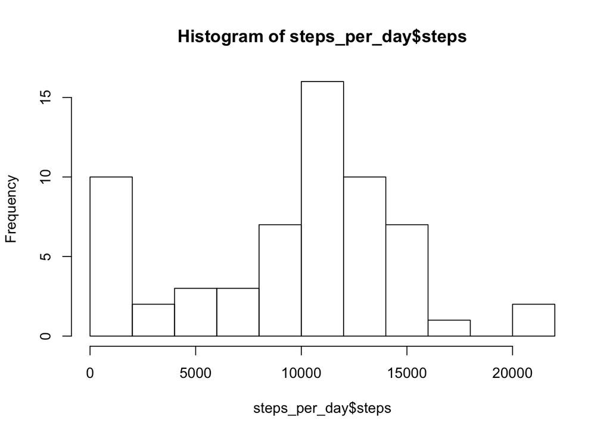

```r
# set breaks to 10 to make the histogram show more details
hist(steps_per_day$steps,breaks=10)
```

Calculate and report the mean and median of the total number of steps taken per day

```r
# Caculate the mean and median of steps
steps_mean=mean(steps_per_day$steps)
steps_median=median(steps_per_day$steps)
# print the results
print(paste('The mean of steps per day is',round(steps_mean,2),'and',
      paste("The median of steps per day is",steps_median)))
```

```
## [1] "The mean of steps per day is 9354.23 and The median of steps per day is 10395"
```

## 3.Caculate the average daily activity pattern

time series plot (i.e. type = “l”) of the 5-minute interval (x-axis) and the average number of steps taken, averaged across all days (y-axis)

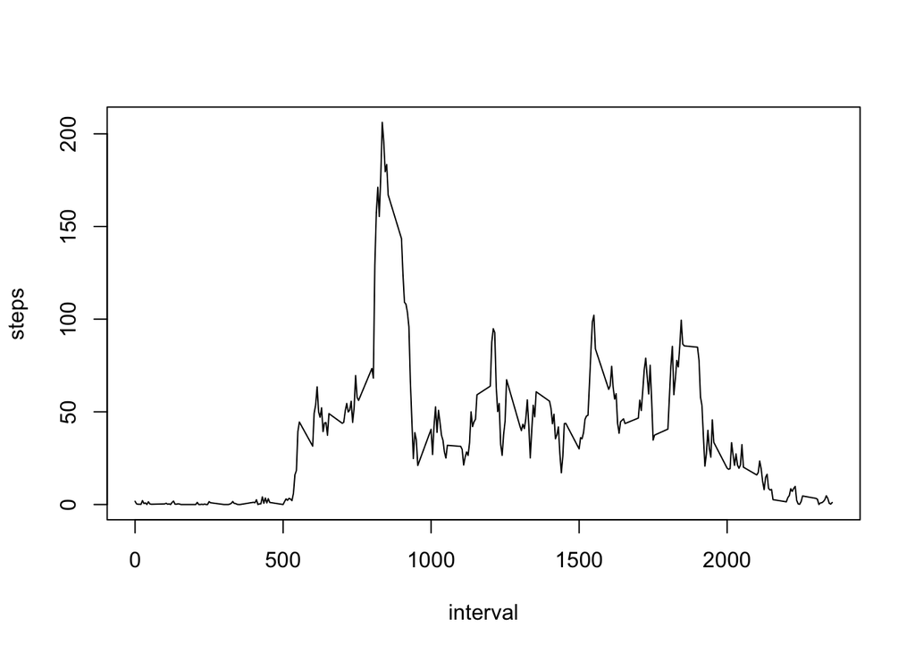

```r
steps_per_interval <- activity %>%
  group_by(interval) %>%
  summarise(steps=mean(steps,na.rm=TRUE))

plot(steps_per_interval,type='l')
```

```r
max_step_interval=steps_per_interval[steps_per_interval$steps==max(steps_per_interval$steps),'interval']

print(paste('The max of the average number of steps taken occur in interval', max_step_interval,'and the max steps is about',round(max(steps_per_interval$steps),0),'steps!'))
```

```
## [1] "The max of the average number of steps taken occur in interval 835 and the max steps is about 206 steps!"
```

The max of the average number of steps taken occur at 8:35 AM.

## Imputing missing values

Calculate and report the total number of missing values in the dataset (i.e. the total number of rows with NAs)

```r
steps_missing=sum(is.na(activity$steps))
print(paste('The total number of missing values in the dataset is',steps_missing))
```

```
## [1] "The total number of missing values in the dataset is 2304"
```

filling in all of the missing values in the dataset with mean of steps of relevant interval and Create a new dataset

```r
activity_changed = activity %>%
  left_join(.,steps_per_interval,by="interval") %>%
  mutate(steps.x=ifelse(is.na(steps.x),steps.y,steps.x)) %>%
  select(steps.x,date,interval) %>%
  rename(steps=steps.x)

# the NA in dataset activity changed to mean for relevant 5-minute interval as blow:
head(activity_changed)
```

```
##       steps       date interval
## 1 1.7169811 2012-10-01        0
## 2 0.3396226 2012-10-01        5
## 3 0.1320755 2012-10-01       10
## 4 0.1509434 2012-10-01       15
## 5 0.0754717 2012-10-01       20
## 6 2.0943396 2012-10-01       25
```

Make a histogram of the total number of steps taken each day and Calculate and report the mean and median total number of steps taken per day

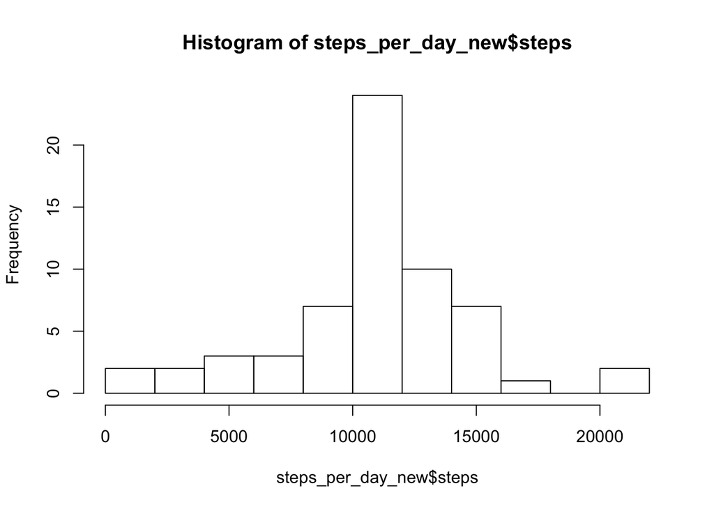

```r
steps_per_day_new <- activity_changed %>%
  group_by(date) %>%
  summarise(steps=sum(steps))

hist(steps_per_day_new$steps,breaks=10)
```

```r
# Caculate the mean and median of steps
steps_mean_new=mean(steps_per_day_new$steps)
steps_median_new=median(steps_per_day_new$steps)
# print the results
print(paste('The mean of steps per day  with missing values filled is',round(steps_mean_new,2),'and',
      paste("The median of steps per day with missing values filled is",round(steps_median_new,2))))
```

```
## [1] "The mean of steps per day  with missing values filled is 10766.19 and The median of steps per day with missing values filled is 10766.19"
```

After missing values in the dataset is imputed by the mean of steps number of relevent interval, the mean step increased from 9354.23 to 10766.19, and median increased from 10395 to 10766.19. It’s worth noting that After imputing, the mean and median of steps become the same.